# 散点图系列二

庄闪闪

2020-10-15

记得安装prettydoc包，html模板在该包渲染而成。

[figure not shown]

欢迎**关注**我的**公众号**，**点赞，在看，收藏~~~**

## 1.前言

**散点图**（scatter graph、point graph、X-Y plot、scatter chart ）是科研绘图中最常见的图表类型之一，通常用于显示和比较数值。散点图是使用一系列的散点在直角坐标系中展示变量的数值分布。在二维散点图中，可以通过观察两个变量的数据变化，发现两者的关系与相关性。

散点图可以提供三类关键信息：

（1）变量之间是否存在数量关联趋势；

（2）如果存在关联趋势，那么其是线性还是非线性的；

（3）观察是否有存在离群值，从而分析这些离群值对建模分析的影响。

本文可以看作是[《R语言数据可视化之美》](https://github.com/EasyChart/Beautiful-Visualization-with-R)的学习笔记。该书第四章——**数据关系型图表**中展示的散点图系列包括以下四个方面：

1. 趋势显示的二维散点图
2. 分布显示的二维散点图
3. 气泡图
4. 三维散点图

本文主要对**第二部分**进行介绍，并加上小编自己的理解。下面几个部分也会在最近陆续推出，敬请关注。

## 3.单数据系列

### 3.1数据格式

这里我们使用正态分布随机产生250个数据（这个就是实际我们采集的一维数据）。`step`是指按照多少的区间进行划分类别。我们通过`hist()`将直方图内部数据进行存储(我也是第一次见这种操作，以后学起来)。输出`hg`.

其中breaks表示边界点，counts表示每个区间内的个数，density表示密度函数值。mids表示区间的中间点，并利用这些参数来构建后续绘图所需要的数据。通过循环语句，计算出x，y坐标数据。 完整代码如下：

```r
#加载包
library(ggplot2)
library(RColorBrewer) #颜色
library(scales)

x <- rnorm(250 , mean=10 , sd=1)
step<-0.2
breaks<- seq(min(x)-step,max(x)+step,step)

hg <- hist(x, breaks = breaks , plot = FALSE)#使用直方图数据，但不绘图

bins <- length(hg$counts) # bin类别数
yvals <- numeric(0)
xvals <- numeric(0)
for(i in 1:bins) {
  yvals <- c(yvals, hg$counts[i]:0)
  xvals <- c(xvals, rep(hg$mids[i], hg$counts[i]+1))
}

dat <- data.frame(xvals, yvals)  # 变成dataframe格式
dat <- dat[yvals > 0, ]          # 去除小于0的数

colormap <- colorRampPalette(rev(brewer.pal(11,'Spectral')))(32) #颜色选择
```

### 3.2原始数据绘制

接下来我们使用该数据（单数据）进行绘制：

- **柱状图（正态分布）**

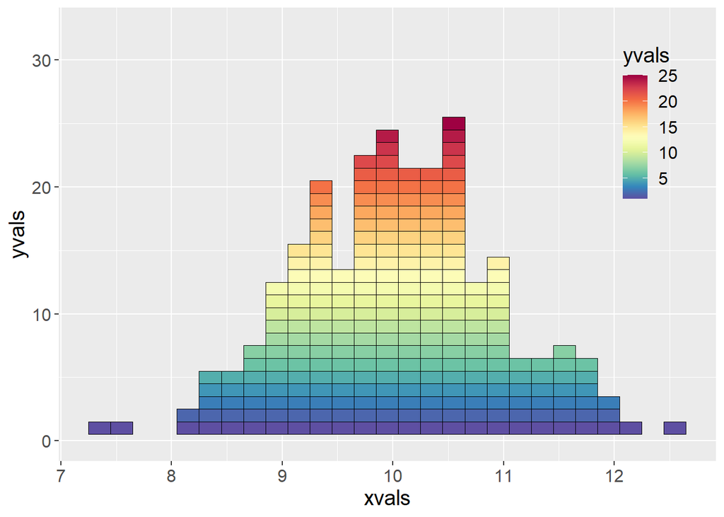

```r
ggplot(dat, aes(x=xvals,y=yvals,fill=yvals))+
  geom_tile(colour="black")+
  scale_fill_gradientn(colours=colormap)+
  ylim (0, max(yvals)*1.3)+
  theme(
    text=element_text(size=15,color="black"),
    plot.title=element_text(size=15,family="myfont",
      face="bold.italic",hjust=.5,color="black"),
    legend.background = element_blank(),
    legend.position=c(0.9,0.75)
  )
```

`geom_tile(colour="black")`改为`geom_point(colour="black",shape=21,size=4)`会得到以下图片

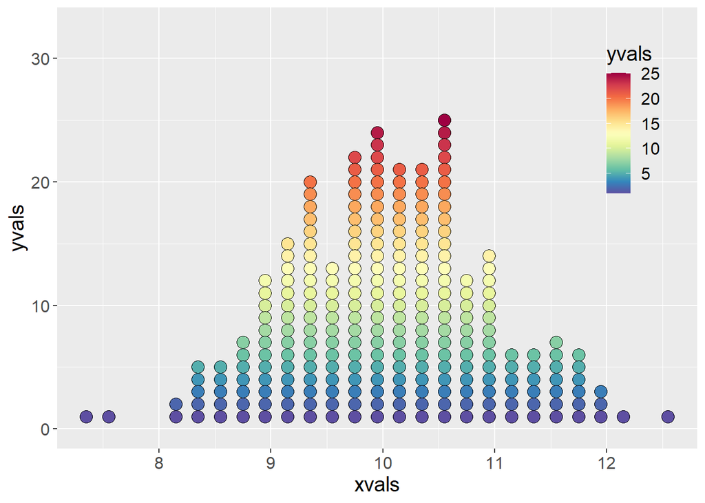

```r
ggplot(dat, aes(x=xvals,y=yvals,fill=yvals))+
  geom_point(colour="black",shape=21,size=4)+
  scale_fill_gradientn(colours=colormap)+
  ylim (0, max(yvals)*1.3)+
  theme(
    text=element_text(size=15,color="black"),
    plot.title=element_text(size=15,family="myfont",face="bold.italic",hjust=.5,color="black"),
    legend.background = element_blank(),
    legend.position=c(0.9,0.75)
  )
```

### 3.3 Q-Q图的绘制

在R中可以使用`CircStats`包的`pp.plot()`函数绘制P-P图；`ggplot2` 包的`geom_qq()`函数和`geom_qq_line()`函数结合可以绘制Q-Q 图；另外，`ggplot2`包结合`ggpubr`包也可以绘制，[当然改包还有其他好用的功能](https://rpkgs.datanovia.com/ggpubr/index.html)。

下面对第三种方式进行实现： `ggpubr`包中的`ggqqplot`相应参数如下，包括了非常多的参数，前两个参数分别表示：数据，要绘制的变量。当然其他数据包括设置主题（`ggtheme`）;添加qqline（`add = c("qqline")）`等。

```
ggqqplot(
  data,  x,  combine = FALSE,  merge = FALSE,  color = "black",  palette = NULL,  size = NULL,  shape = NULL,  add = c("qqline", "none"),  add.params = list(linetype = "solid"),  conf.int = TRUE,  conf.int.level = 0.95,
  title = NULL,  xlab = NULL,  ylab = NULL,  facet.by = NULL,  panel.labs = NULL,  short.panel.labs = TRUE,  ggtheme = theme_pubr(),  ...
)
```

为了更好解释这个函数，我们重新模拟一个数据集。

```r
library(ggpubr)
# 创建一个数据集
set.seed(1234)
wdata = data.frame(
   sex = factor(rep(c("F", "M"), each=200)),
   weight = c(rnorm(200, 55), rnorm(200, 58)))
head(wdata, 4)
```

```
##   sex   weight
## 1   F 53.79293
## 2   F 55.27743
## 3   F 56.08444
## 4   F 52.65430
```

[output not shown]

[output not shown]

### 3.4 带透明度设置的散点图

- 数据设定

这个数据是张杰老师书中的数据，是经过一定处理得到的，结果图可以看下面。

```r
library(ggplot2)
library(RColorBrewer)

mydata<-read.csv("HighDensity_Scatter_Data.csv",stringsAsFactors=FALSE)
head(mydata)
```

```
##            x          y
## 1 -0.6035329 -0.4125721
## 2  0.1387146  0.1735841
## 3  0.5422206 -0.4600465
## 4 -1.1728489 -0.1436682
## 5  0.2145623 -0.2755651
## 6  0.2530279  0.4243228
```

我们利用`ggplot()`简单绘制二维数据的散点图，之后在对该数据进行聚类。

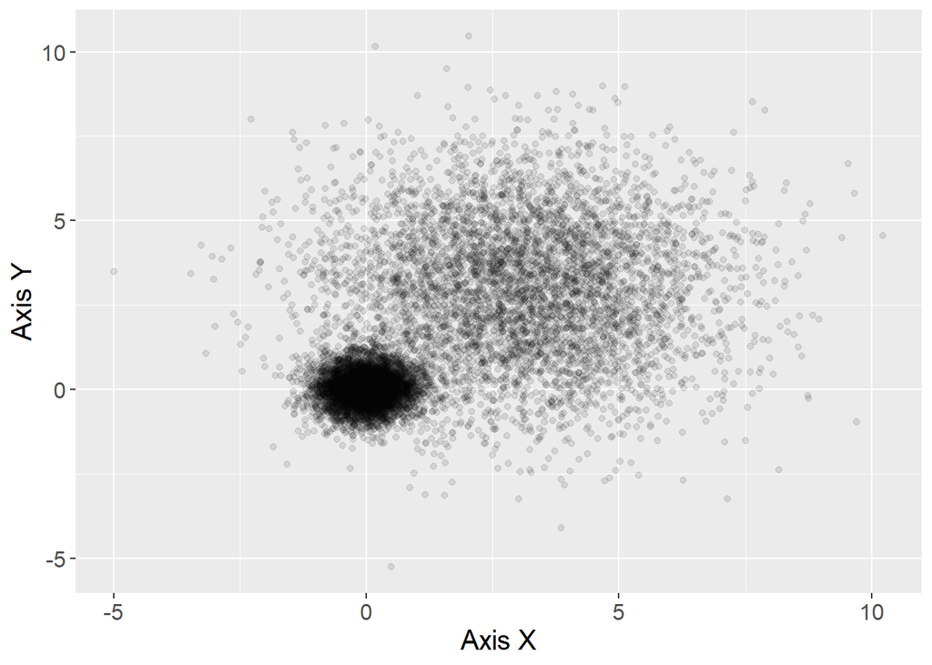

```r
ggplot(data = mydata, aes(x,y)) +
  geom_point( colour="black",alpha=0.1)+
  labs(x = "Axis X",y="Axis Y")+
  theme(
    text=element_text(size=15,color="black"),
    plot.title=element_text(size=15,family="myfont",face="bold.italic",hjust=.5,color="black"),
    legend.position="none"
  )
```

### 3.5 kmeans聚类的散点图

对上面数据进行kmeans聚类，这里使用base中的 `kmeans()`进行分类（两类），然后将分类情况(`cluster`)进行存储，并转化成因子类型。绘图时，cluster来设置颜色，这样就可以很明显看出分类结果。

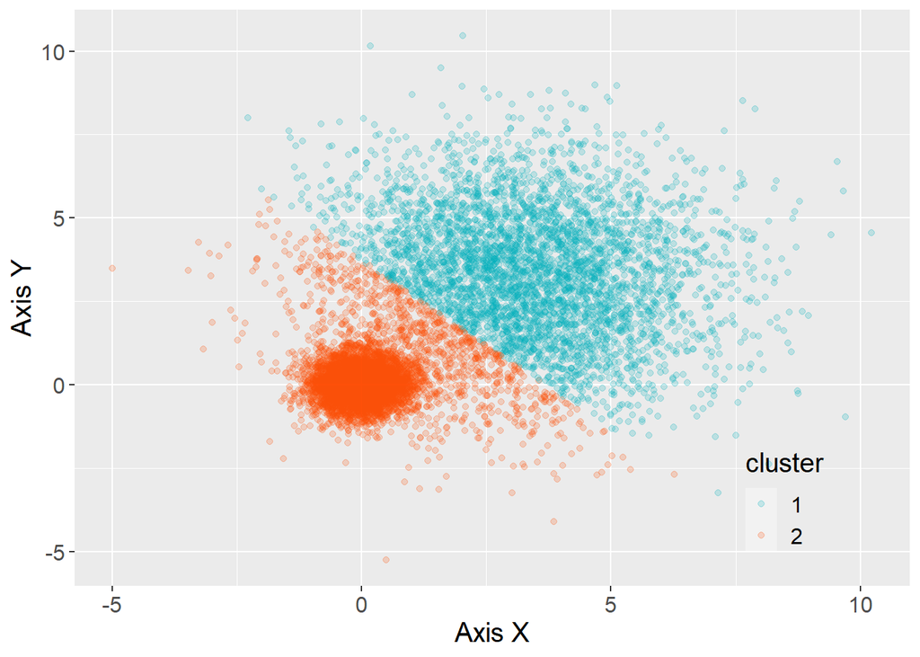

```r
kmeansResult<- kmeans(mydata, 2, nstart = 20)
mydata$cluster <- as.factor(kmeansResult$cluster)
ggplot(data = mydata, aes(x,y,color=cluster)) +
  geom_point( alpha=0.2)+
  scale_color_manual(values=c("#00AFBB",  "#FC4E07"))+
  labs(x = "Axis X",y="Axis Y")+
  theme(
    text=element_text(size=15,color="black"),
    plot.title=element_text(size=15,family="myfont",face="bold.italic",color="black"),
    legend.background=element_blank(),
    legend.position=c(0.85,0.15)
  )
```

### 3.6 带椭圆标定的聚类散点图

有时候我们想突出聚类结果会在结果上画上椭圆，那么可以使用`stat_ellipse()`。

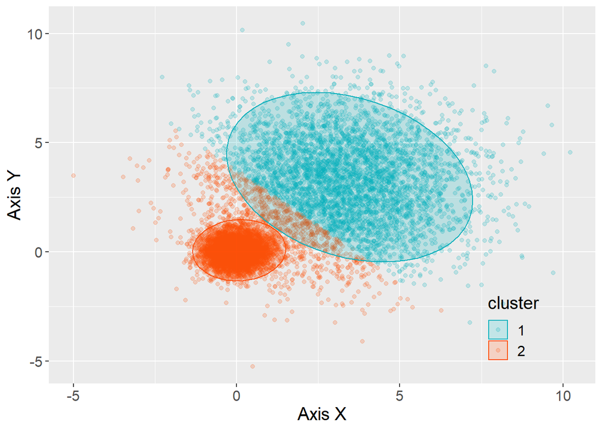

```r
ggplot(data = mydata, aes(x,y,color=cluster)) +
  geom_point (alpha=0.2)+  # 绘制透明度为0.2 的散点图
  stat_ellipse(aes(x=x,y=y,fill= cluster), geom="polygon", level=0.95, alpha=0.2)+#绘制椭圆标定不同类别
  scale_color_manual(values=c("#00AFBB","#FC4E07"))+#使用不同颜色标定不同数据类别
  scale_fill_manual(values=c("#00AFBB","#FC4E07"))+#使用不同颜色标定不同椭类别
  labs(x = "Axis X",y="Axis Y")+
  theme(
    text=element_text(size=15,color="black"),
    plot.title=element_text(size=15,family="myfont",face="bold.italic",color="black"),
    legend.background=element_blank(),
    legend.position=c(0.85,0.15)
  )
```

## 3.7 多数据系列

多数据系列，其实在聚类散点图就已经涉及到。这里对较少数据进行绘制，这样看起来结果更加美观。

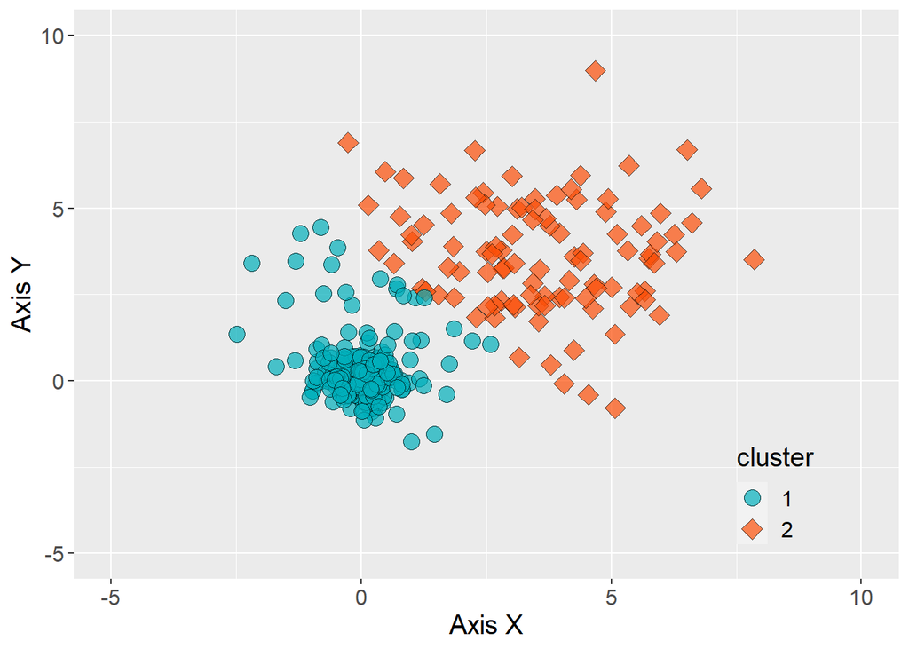

```r
mydata<-mydata[round(runif(300,0,10000)),]
kmeansResult<- kmeans(mydata, 2, nstart = 20)
mydata$cluster <- as.factor(kmeansResult$cluster)
ggplot(data = mydata, aes(x,y,fill=cluster,shape=cluster)) +
  geom_point(size=4,colour="black",alpha=0.7)+
  scale_shape_manual(values=c(21,23))+
  scale_fill_manual(values=c("#00AFBB",  "#FC4E07"))+
  labs(x = "Axis X",y="Axis Y")+
  scale_y_continuous(limits = c(-5, 10))+
  scale_x_continuous(limits = c(-5, 10))+
  theme(
    text=element_text(size=15,color="black"),
    plot.title=element_text(size=15,family="myfont",face="bold.italic",color="black"),
    legend.background=element_blank(),
    legend.position=c(0.85,0.15)
  )
```